# TreePhenologyAnalysis

## Import required packaes from python

```python
import pandas as pd

from pyinaturalist import get_observations

from pyinaturalist_convert import to_dataframe
```

```
## No module named 'pyinaturalist.response_format'
```

## Selected Species - Native Trees

The species of interest for this analysis are the native trees of the British Isles. The definition of a ‘native’ tree is partially subjective, depending on the time of seperation from Europe, the height a self-supported woody plant must reach, and distinction between a species and micro-species. For this analysis I use the following list.

```python
selected_species = ["Acer campestre", "Alnus glutinosa", "Arbutus unedo", "Betula pendula", "Betula pubescens",  "Buxus sempervirens", "Carpinus betulus", "Cornus sanguinea", "Corylus avellana", "Crataegus laevigata", "Crataegus monogyna", "Euonymus europaeus", "Fagus sylvatica", "Frangula alnus", "Fraxinus excelsior", "Hippophae rhamnoides", "Ilex aquifolium", "Juniperus communis", "Ligustrum vulgare", "Malus sylvestris", "Pinus sylvestris", "Populus nigra", "Populus tremula", "Prunus avium", "Prunus padus", "Prunus spinosa", "Quercus petraea", "Quercus robur", "Rhamnus cathartica", "Salix caprea", "Salix cinerea", "Salix pentandra", "Salix phylicifolia", "Sambucus nigra", "Sorbus aria", "Sorbus aucuparia", "Sorbus domestica", "Sorbus torminalis", "Taxus baccata", "Tilia cordata", "Tilia platyphyllos", "Tilia x europaea", "Ulmus glabra", "Ulmus minor", "Viburnum lantana", "Viburnum opulus"]
```

The python package `pyinaturalist` facilitates the efficient retrieval of data from the iNaturalist platform via their API. Particularly useful is the ability to retrieve observations based on the additional ‘Observation’ and ‘Annotations’ fields.

Data retrieved via `pyinaturalist` is returned in JSON format; the package `pyinaturalist-convert` provides useful functions to convert data retrieved from iNaturalist into a variety of output formats. For the purposes of this analysis, the iNaturalist data is simply returned as a tidy data frame for use in this R Markdown document.

iNaturalist state that “Please note that we throttle API usage to a max of 100 requests per minute, though we ask that you try to keep it to 60 requests per minute or lower, and to keep under 10,000 requests per day. If we notice usage that has serious impact on our performance we may institute blocks without notification.” (https://api.inaturalist.org/v1/docs/). So ensure that the search terms you are using don’t result in these limits being exceeded.

## Switch to R, tidy dates

After retrieving the required data in Python a switch to the R language is made, to tidy the data using the `lubridate` package.

```r
fruiting_data_r <- py$fruiting_data
fruiting_r_trimmed <- fruiting_data_r |>
  dplyr::filter(time_observed_at != "NULL") |>
  dplyr::mutate(time_observed_at = lubridate::ymd_hms(time_observed_at)) |>
  dplyr::mutate(month = lubridate::month(time_observed_at)) |>
  dplyr::mutate(yday = lubridate::yday(time_observed_at))
```

## Inspect data

Before creating a calendar the distribution of the data must be inspected.

Observations for the fruiting time of trees in iNaturalist appear to include various stages of a fruits development, rather than the time when the fruit was observed to be ripe, or the ‘first ripe fruit’ as in the Woodland Trust’s Nature’s Calendar project.

To ensure that our mean seed collection time is not skewed the observations with dates outside the reasonable range of when a fruit is ripe need to be excluded.

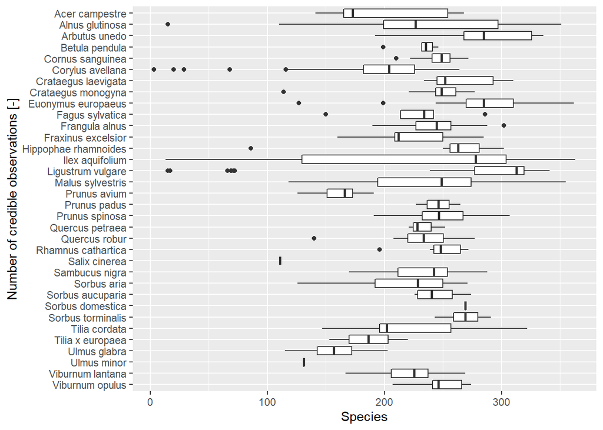

```r
boxplot <- ggplot2::ggplot(fruiting_r_trimmed, ggplot2::aes(x = yday,
                                                            y = forcats::fct_rev(species))
                           ) +
  ggplot2::geom_boxplot() +
  # ggplot2::coord_flip() +
  ggplot2::xlab("Species") +
  ggplot2::ylab("Number of credible observations [-]")

boxplot
```

## Manually clean data

To do this I note that observations are “Mis-recorded” if they are outside the probable range, and “Probably ok” if they are inside the probable range; with the probable range being determined by a review of the literature. The observations which are “Mis-recorded” are then removed.

```r
fruiting_r_cleaned <- fruiting_r_trimmed |>
  dplyr::mutate(
    status = dplyr::case_when(
      species == "Acer campestre" & month > 11 | species == "Acer campestre" & month < 8 ~ "Mis-recorded",
      species == "Alnus glutinosa" & month > 12 | species == "Alnus glutinosa" & month < 8 ~ "Mis-recorded",
      # species == "Arbutus unedo" & month > 11 | species == "Arbutus unedo" & month < 8 ~ "Mis-recorded",
      # species == "Betula pendula"
      # species == "Betula pubescens"
      # species == "Carpimus betulus"
      species == "Cornus sanguinea" & month > 11 | species == "Cornus sanguinea" & month < 8 ~ "Mis-recorded",
      species == "Corylus avellana" & month > 11 | species == "Corylus avellana" & month < 8 ~ "Mis-recorded",
      species == "Crataegus laevigata" & month > 12 | species == "Crataegus laevigata" & month < 8 ~ "Mis-recorded",
      species == "Crataegus monogyna" & month > 12 | species == "Crataegus monogyna" & month < 8 ~ "Mis-recorded",
      species == "Euonymus europaeus" & month > 12 | species == "Euonymus europaeus" & month < 8 ~ "Mis-recorded",
      species == "Fagus sylvatica" & month > 12 | species == "Fagus sylvatica" & month < 8 ~ "Mis-recorded",
      species == "Frangula alnus" & month > 11 | species == "Frangula alnus" & month < 8 ~ "Mis-recorded",
      species == "Fraxinus excelsior" & month > 12 | species == "Fraxinus excelsior" & month < 7 ~ "Mis-recorded",
      species == "Hippophae rhamnoides" & month > 3 & month < 8 ~ "Mis-recorded",
      species == "Ilex aquifolium" & month > 3 & month < 10 ~ "Mis-recorded",
      # species == "Juniperus communis"
      # species == "Ligustrum vulgare" & month > 11 | species == "Ligustrum vulgare" & month < 8 ~ "Mis-recorded",
      species == "Malus sylvestris" & month > 11 | species == "Malus sylvestris" & month < 8 ~ "Mis-recorded",
      # species == "Pinus sylvestris"
      # species == "Populus nigra subsp. betulifolia"
      # species == "Populus tremula"
      species == "Prunus avium" & month > 8 | species == "Prunus avium" & month < 6 ~ "Mis-recorded",
      # species == "Prunus padus"
      species == "Prunus spinosa" & month > 11 | species == "Prunus spinosa" & month < 8 ~ "Mis-recorded",
      # species == "Quercus petraea"
      species == "Quercus robur" & month > 12 | species == "Quercus robur" & month < 8 ~ "Mis-recorded",
      species == "Rhamnus cathartica" & month > 11 | species == "Rhamnus cathartica" & month < 9 ~ "Mis-recorded",
      # species == "Salix spp."
      species == "Sambucus nigra" & month > 11 | species == "Sambucus nigra" & month < 8 ~ "Mis-recorded",
      species == "Sorbus aria" & month > 10 | species == "Sorbus aria" & month < 8 ~ "Mis-recorded",
      species == "Sorbus aucuparia" & month > 11 | species == "Sorbus aucuparia" & month < 7 ~ "Mis-recorded",
      # species == "Sorbus domestica"
      # species == "Sorbus torminalis"
      # species == "Taxus baccata"
      species == "Tilia cordata" & month > 11 | species == "Tilia cordata" & month < 9 ~ "Mis-recorded",
      # species == "Tilia platyphyllos"
      species == "Tilia x europaea" & month > 11 | species == "Tilia x europaea" & month < 9 ~ "Mis-recorded",
      species == "Ulmus glabra" & month > 7 | species == "Ulmus glabra" & month < 4 ~ "Mis-recorded",
      # species == "Ulmus minor"
      species == "Viburnum lantana" & month > 10 | species == "Viburnum lantana" & month < 6 ~ "Mis-recorded",
      species == "Viburnum opulus" & month > 10 | species == "Viburnum opulus" & month < 7 ~ "Mis-recorded",
      TRUE ~ "Probably ok"
    )
  ) |>
  dplyr::filter(status != "Mis-recorded") |>
  dplyr::select(-status)
```

## Plot observation counts

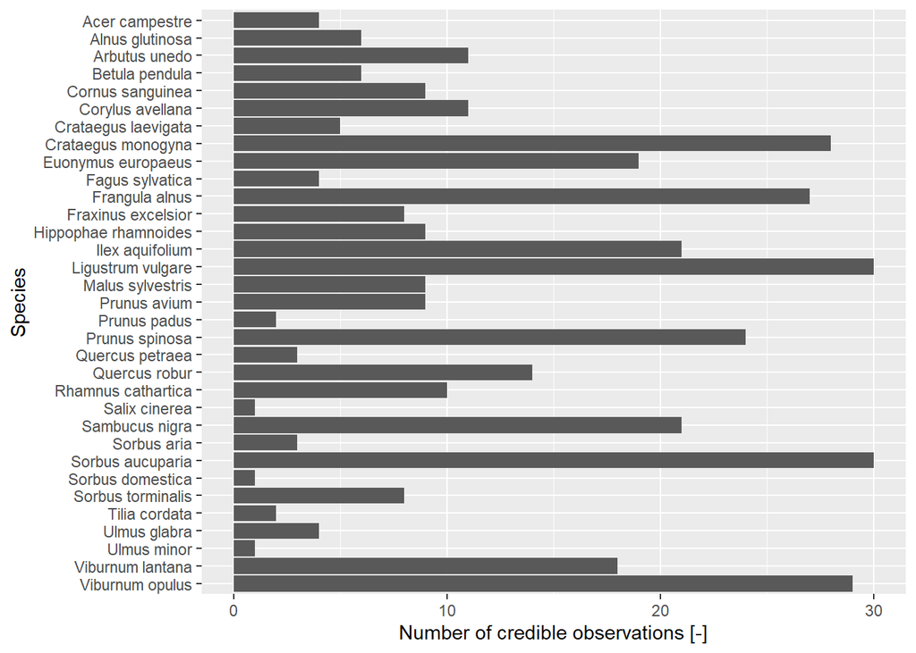

```r
fruiting_count <- fruiting_r_cleaned |>
  dplyr::count(species)

count_barchart <- ggplot2::ggplot(fruiting_r_cleaned, ggplot2::aes(forcats::fct_rev(species))) +
  ggplot2::geom_bar() +
  ggplot2::coord_flip() +
  ggplot2::xlab("Species") +
  ggplot2::ylab("Number of credible observations [-]")

aspect_ratio_bc <- 2
height_bc <- 8
ggplot2::ggsave("count_barchart.png", height = height_bc, width = height_bc * aspect_ratio_bc)


count_barchart
```